# Data visualization

## Variable assignment

En primer lugar vamos a proceder a crearnos un nuevo conjunto de datos que contiene información del conjunto de datos gapminder filtrado por el año 1952.

```r
#Cargamos librerías
library(dplyr)
library(gapminder)
library(ggplot2)
#Ahora procedemos a crearnos nuestro conjunto de datos
gapminder_1952 <- gapminder %>% filter(year == 1952)
```

## Comparing population and GDP per capita

A continuación vamos a proceder a hacer uso del paquete ggplot2 para proceder a visualizar si existe alguna relación entre la población y la renta per capita de un país. Para ello vamos a proceder a hacer un grafo de tipo scatter plot

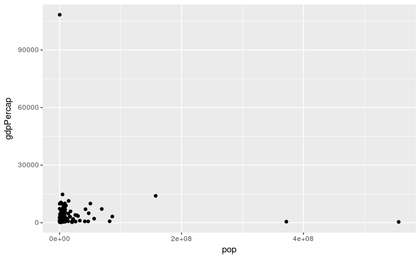

```r
#Hahcemos el grafo
ggplot(gapminder_1952, aes(x = pop, y = gdpPercap)) + geom_point()
```

## Comparing population and life expectancy

A continuación vamos a proceder a crearnos un scatter plot para intentar ver si existe algún tipo de relación entre la esperanza de vida y la población.

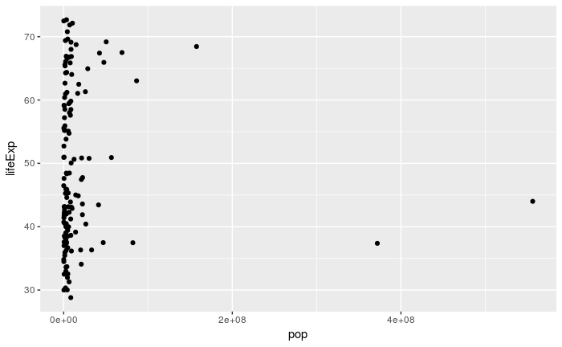

```r
#Nos creamos el scatter
ggplot(gapminder_1952, aes(x = pop, y = lifeExp)) + geom_point()
```

## Putting the x-axis on a log scale

Anteriormente hemos creado un gráfico de tipo scatter donde en el eje x tenemos la pobalción de países y en el eje y la esperanza de vida. Puesto que la población se distribuye en distintos órdene de magnitud, ya que algunos países tienen mucha más población que otros, es una buena idea poner ele eje x en escala logarítmica.

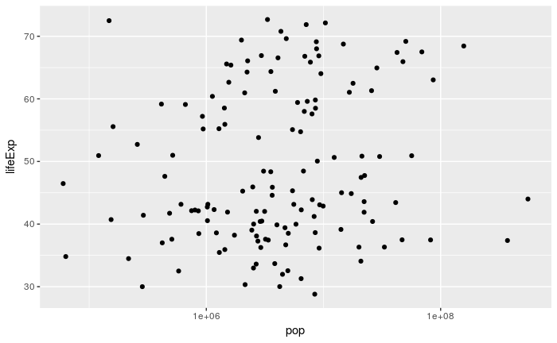

```r
#Hacemos un scatter de población vs esperanza de vida con el eje x en escala logarítmica
ggplot(gapminder_1952, aes(x = pop, y = lifeExp)) + geom_point() + scale_x_log10()
```

Ahora es posible ver de una forma más clara que no existe correlación alguna entra la población de un país y su esperanza de vida.

## Putting the x- and y- axes on a log scale

Si queremos por ejemplo hacer un scatter plot con la población en el eje X y la renta per capita en el eje Y, en este caso ambas magnitudes tienen una distribución muy desigual, por lo que es mejor poner ambas en escala logarítmica.

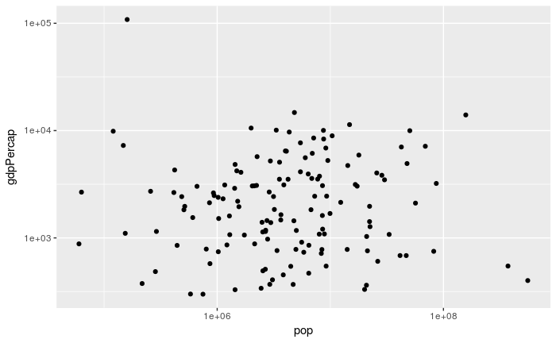

```r
ggplot(gapminder_1952, aes(x = pop, y = gdpPercap)) + geom_point() + scale_x_log10() + scale_y_log10()
```

## Adding color to a scatter plot

El parámetro **aes()** dispone del argumento **color** que nos permite agregar color a nuestro gráfico. Por ejemplo, si tenemos una variable de tipo categórica, entonces nos agregará un color para cada categoría.

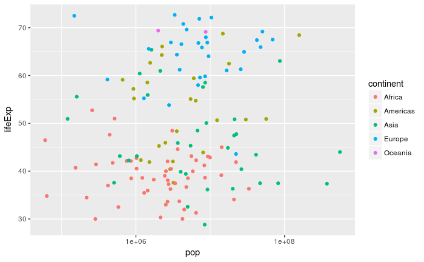

```r
#Nos creamos un gráfico de tipo scatter entre la pobración y la esperanza de vida identificando cada país por un color
ggplot(gapminder_1952, aes(x = pop, y = lifeExp, color = continent)) + geom_point() + scale_x_log10()
```

## Adding size and color to a plot

También disponemos del argumento **size** dentro del parámetro **aes()** que nos permite asignar a cada punto un tamaño en función de alguna variable de interés.

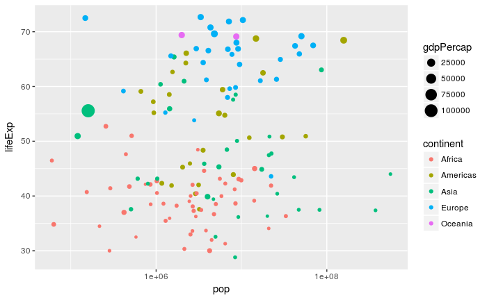

```r
#Nos creamos un gráfico de tipo scatter entre la población y la esperanza de vida identificando cada continente por un color y el
#tamaño de cada punto por la renta per capita
ggplot(gapminder_1952, aes(x = pop, y = lifeExp, color = continent, size = gdpPercap)) + geom_point() + scale_x_log10()
```

## Creating a subgraph for each continent

La librería **ggplot2** nos permite crear subplots, en función de los distintos valores que toma una variable categórica, para ello disponemos de **facet_wrap()**.

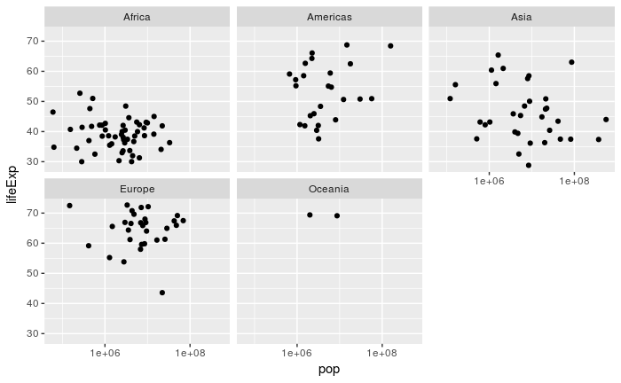

```r
#Nos creamos un scatter plot por continente
ggplot(gapminder_1952, aes(x = pop, y = lifeExp)) + geom_point() + scale_x_log10() + facet_wrap(~ continent)
```

## Faceting by year

A continuación vamos a proceder a realizar un gráfico por año, donde representaremos si existe alguna relación entre la renta per capita de un país y la esperanza de vida.

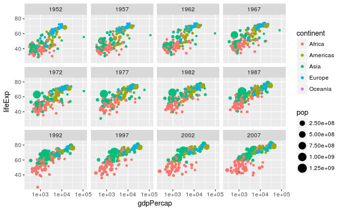

```r
ggplot(gapminder, aes(x = gdpPercap, y = lifeExp, color = continent, size = pop)) + geom_point() + scale_x_log10() + facet_wrap(~ year)
```